# Breathtaking Plots and Graphs - All Students

Keri and David

7/26/2017

Long and Wide dataframes of “TRUE SURVIVORS’S ##PERFORMANCE”

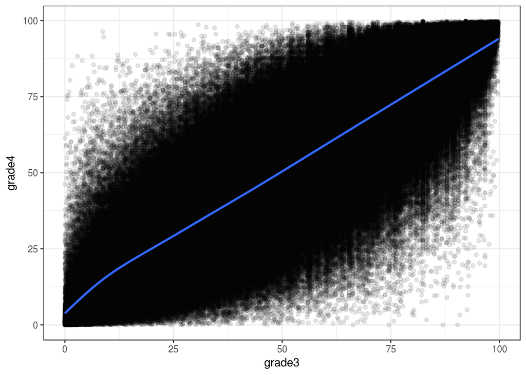

```r
student_unique_performance <-
avg_all_percentile %>%
  group_by(student_id_scram, grade_level) %>%
  summarize(percentile = max(performance))

#Cleaning up data
student_unique_performance_long <-
  student_unique_performance %>%
  filter(!(is.na(grade_level) | is.na(student_id_scram) | is.na(percentile))) %>%
  filter(grade_level >= 3)

student_unique_performance_wide <-
  student_unique_performance_long %>%
  spread(grade_level, percentile)

colnames(student_unique_performance_wide) <-
  c("student_id_scram","grade3","grade4","grade5","grade6",
    "grade7","grade8","grade9","grade10","grade11","grade12")

graph3to4 <-
  student_unique_performance_wide %>%
  ggplot(aes(x=grade3, y=grade4)) +
  geom_point(alpha=0.1) +
  geom_smooth()
plot(graph3to4)
```

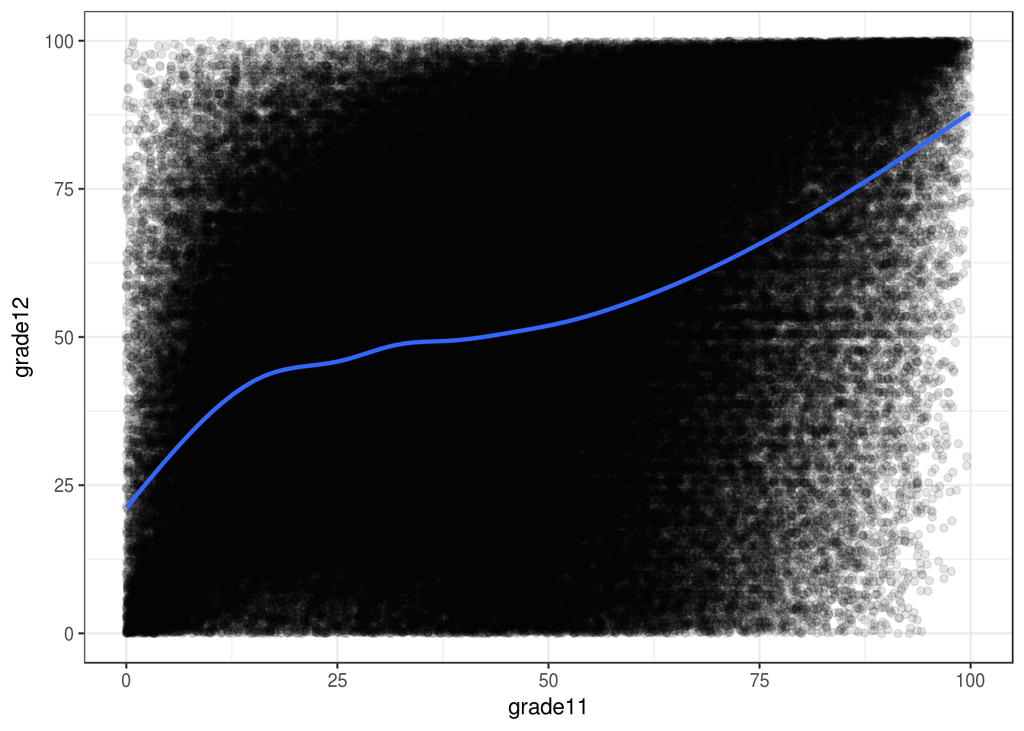

```r
graph8to12 <-
  student_unique_performance_wide %>%
  ggplot(aes(x=grade11, y=grade12)) +
  geom_point(alpha=0.1) +
  geom_smooth()
plot(graph8to12)
```

compare 4th and 8th. Bin every 5 percent, calculate the quantiles in those bins. graph

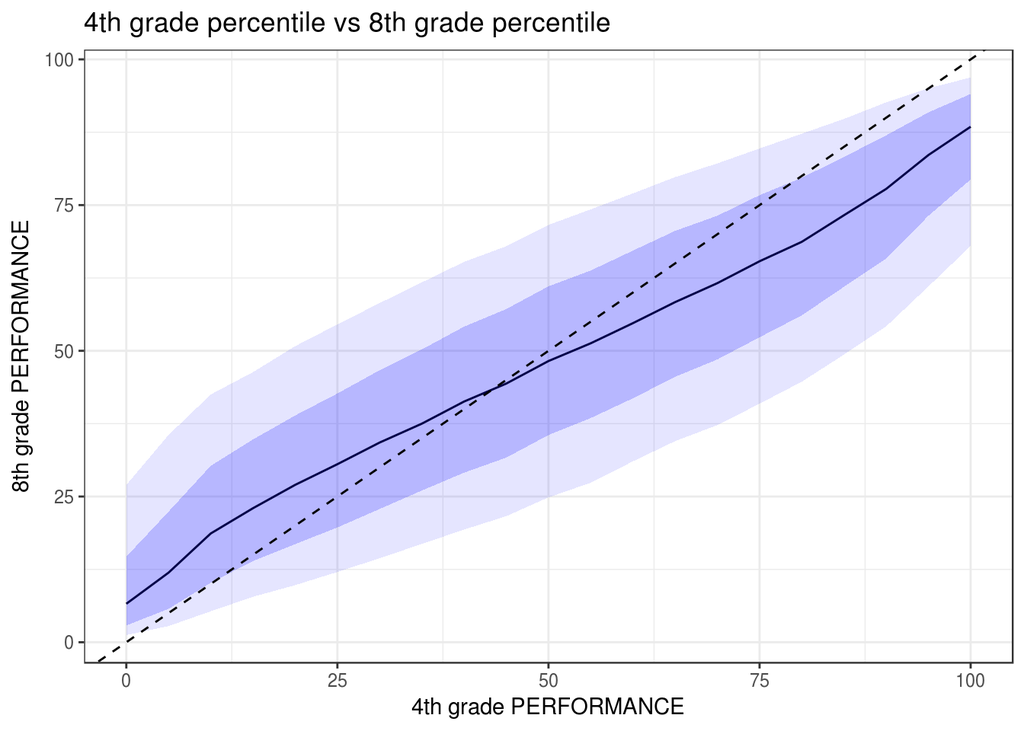

```r
student_unique_performance_wide %>%
  select(student_id_scram,grade4,grade8)%>%
  filter(!(is.na(grade4)|is.na(grade8)))%>%
  mutate(bin=round(grade4/5)*5) %>%
  group_by(bin) %>%
  summarize(lower=quantile(grade8, 0.25), mid = quantile(grade8, 0.5), upper=quantile(grade8,0.75), low=quantile(grade8,0.10), high=quantile(grade8,0.9)) %>%
  ggplot(aes(x= bin, y= mid)) +
  geom_line()+
  geom_ribbon(aes(ymin=lower, ymax=upper), alpha=0.2, fill="blue") +
  geom_ribbon(aes(ymin=low, ymax=high), alpha= 0.1,fill="blue") +
  geom_abline(linetype = "dashed") +
  labs(title="4th grade percentile vs 8th grade percentile", x="4th grade PERFORMANCE", y="8th grade PERFORMANCE" )
```

FUNCTION FOR PLOTTING GRADES AGAINST EACH OTHER

DOESNT WORK, DONT KNOW WHY

# use standard eval hack to plot variable columns

# more here: http://dplyr.tidyverse.org/articles/programming.html

LOOK AT PROGRESSION OF TOP 10 PERCENT OF 3RD GRADE

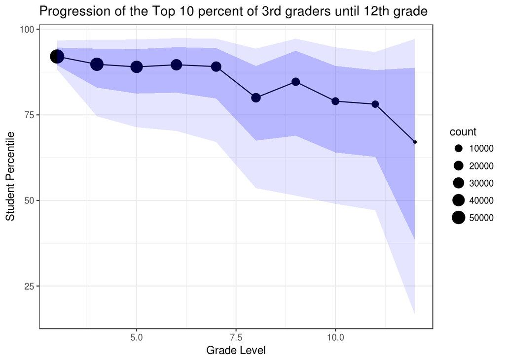

```r
top_10_in_3 <-
  student_unique_performance_wide %>%
  select(student_id_scram,grade3) %>%
  filter(!is.na(grade3))%>%
  mutate(bin=round(grade3/5)*5) %>%
  filter(bin >= 90) %>%
  select(student_id_scram)

wide_10_in_3 <- left_join(top_10_in_3, student_unique_performance_wide, by="student_id_scram")
long_10_in_3 <-
  wide_10_in_3 %>%
  gather(key="grade_level", value="percentile", 2:11) %>%
  select(student_id_scram, grade_level, percentile) %>%
  filter(!is.na(percentile))%>%
  group_by(grade_level) %>%
  summarize(lower=quantile(percentile, 0.25), mid = quantile(percentile, 0.5), upper=quantile(percentile,0.75),
            low=quantile(percentile,0.10), high=quantile(percentile,0.9), count=n()) %>%
  mutate(grade_level = as.numeric(substr(grade_level,6,7)))

graph_long_10_in_3  <-
  long_10_in_3 %>%
  ggplot(aes(x = grade_level, y= mid)) +
  geom_line()+
  geom_point(aes(size=count))+
  geom_ribbon(aes(ymin=lower, ymax=upper), alpha=0.2, fill="blue") +
  geom_ribbon(aes(ymin=low, ymax=high), alpha= 0.1,fill="blue") +
  labs(title = "Progression of the Top 10 percent of 3rd graders until 12th grade",
       x = "Grade Level", y = "Student Percentile")

plot(graph_long_10_in_3)
```

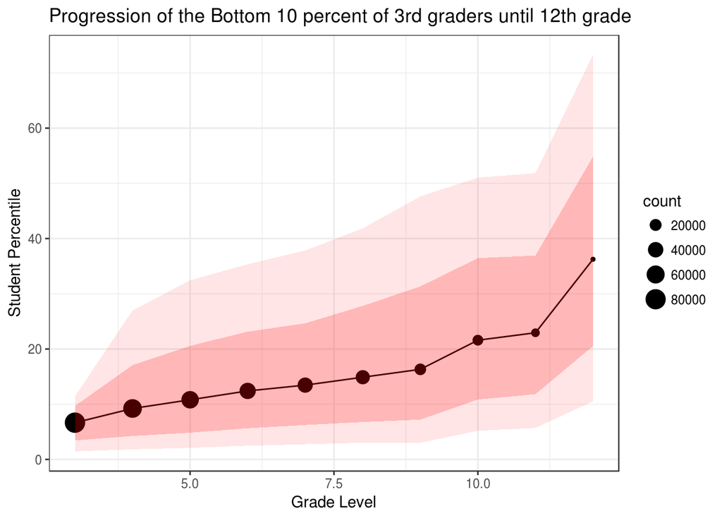

```r
bot_10_in_3 <-
  student_unique_performance_wide %>%
  select(student_id_scram,grade3) %>%
  filter(!is.na(grade3))%>%
  mutate(bin=round(grade3/5)*5) %>%
  filter(bin <= 10) %>%
  select(student_id_scram)

wide_10_in_3 <- left_join(bot_10_in_3, student_unique_performance_wide, by="student_id_scram")

long_10_in_3 <-
  wide_10_in_3 %>%
  gather(key="grade_level", value="percentile", 2:11) %>%
  select(student_id_scram, grade_level, percentile) %>%
  filter(!is.na(percentile))%>%
  group_by(grade_level) %>%
  summarize(lower=quantile(percentile, 0.25), mid = quantile(percentile, 0.5), upper=quantile(percentile,0.75),
            low=quantile(percentile,0.10), high=quantile(percentile,0.9), count=n()) %>%
  mutate(grade_level = as.numeric(substr(grade_level,6,7)))

graph_long_10_in_3  <-
  long_10_in_3 %>%
  ggplot(aes(x = grade_level, y= mid)) +
  geom_line()+
  geom_point(aes(size=count))+
  geom_ribbon(aes(ymin=lower, ymax=upper), alpha=0.2, fill="red") +
  geom_ribbon(aes(ymin=low, ymax=high), alpha= 0.1,fill="red") +
  labs(title = "Progression of the Bottom 10 percent of 3rd graders until 12th grade",
       x = "Grade Level", y = "Student Percentile")

plot(graph_long_10_in_3)
```

```r
read_june_with_year <- function(filename) {
  year <- as.numeric(gsub('-.*$', '', basename(filename)))
  df <- read_csv(filename, col_types = cols(student_id_scram = col_character(), grade_level = col_integer(), ethnicity = col_character()))
  df <- select(df, student_id_scram, ethnicity)
}

files <- Sys.glob('/data/nycdoe/June Biog/*.csv')
ethnicity<- map_df(files, read_june_with_year)
```

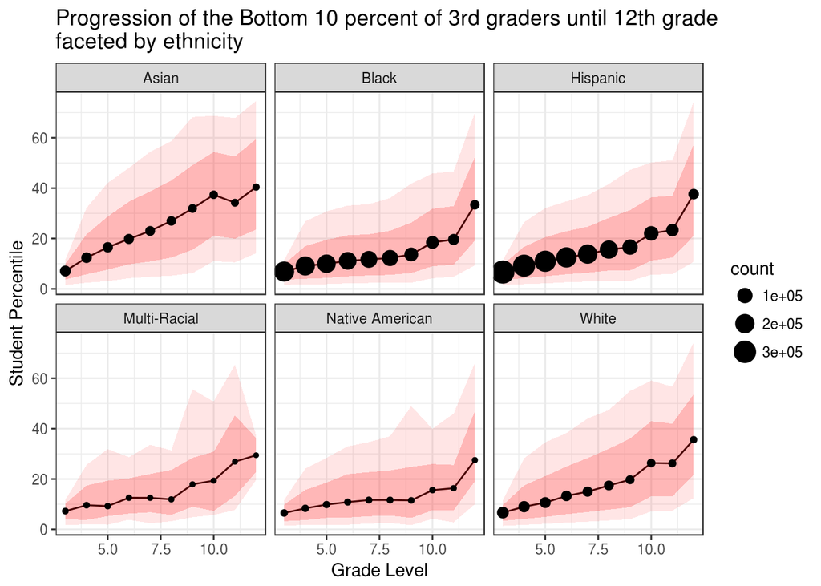

```r
bot_10_in_3 <-
  student_unique_performance_wide %>%
  select(student_id_scram,grade3) %>%
  filter(!is.na(grade3))%>%
  mutate(bin=round(grade3/5)*5) %>%
  filter(bin <= 10) %>%
  select(student_id_scram)

bot_wide_10_in_3 <- left_join(bot_10_in_3, student_unique_performance_wide, by="student_id_scram")
eth_bot_10 <- left_join(bot_wide_10_in_3, ethnicity, by="student_id_scram")

top_10_in_3 <-
  student_unique_performance_wide %>%
  select(student_id_scram,grade3) %>%
  filter(!is.na(grade3))%>%
  mutate(bin=round(grade3/5)*5) %>%
  filter(bin >= 90) %>%
  select(student_id_scram)

top_wide_10_in_3 <- left_join(bot_10_in_3, student_unique_performance_wide, by="student_id_scram")
eth_top_10 <- left_join(top_wide_10_in_3, ethnicity, by="student_id_scram")

long_eth_bot_10 <-
  eth_bot_10 %>%
  gather(key="grade_level", value="percentile", 2:11) %>%
  select(student_id_scram, grade_level, percentile, ethnicity) %>%
  filter(!(is.na(percentile) | is.na(ethnicity)))%>%
  mutate(grade_level = as.numeric(substr(grade_level,6,7))) %>%
  filter(!(ethnicity=='.')) %>%
  group_by(grade_level, ethnicity) %>%
  summarize(lower=quantile(percentile, 0.25), mid = quantile(percentile, 0.5), upper=quantile(percentile,0.75),
            low=quantile(percentile,0.10), high=quantile(percentile,0.9),count=n())

long_eth_bot_10 %>%
  ggplot(aes(x = grade_level, y= mid)) +
  geom_line()+
  geom_ribbon(aes(ymin=lower, ymax=upper), alpha=0.2, fill="red") +
  geom_ribbon(aes(ymin=low, ymax=high), alpha= 0.1,fill="red") +
  geom_point(aes(size=count))+
  facet_wrap(~ethnicity) +
  labs(title = "Progression of the Bottom 10 percent of 3rd graders until 12th grade\nfaceted by ethnicity",
       x = "Grade Level", y = "Student Percentile")
```

[figure not shown]

```r
long_eth_top_10 <-
  eth_top_10 %>%
  gather(key="grade_level", value="percentile", 2:11) %>%
  filter(!(is.na(percentile) | is.na(ethnicity)))%>%
  select(student_id_scram, grade_level, percentile, ethnicity) %>%
  mutate(grade_level = as.numeric(substr(grade_level,6,7))) %>%
  filter(!(ethnicity=='.')) %>%
  group_by(grade_level, ethnicity) %>%
  summarize(lower=quantile(percentile, 0.25), mid = quantile(percentile, 0.5), upper=quantile(percentile,0.75),
            low=quantile(percentile,0.10), high=quantile(percentile,0.9),count=n())

long_eth_top_10 %>%
  ggplot(aes(x = grade_level, y= mid)) +
  geom_line()+
  geom_ribbon(aes(ymin=lower, ymax=upper), alpha=0.2, fill="blue") +
  geom_ribbon(aes(ymin=low, ymax=high), alpha= 0.1,fill="blue") +
  geom_point(aes(size=count))+
  facet_wrap(~ethnicity) +
  labs(title = "Progression of the Top 10 percent of 3rd graders until 12th\ngrade faceted by ethnicity",
       x = "Grade Level", y = "Student Percentile")
```

Sanity Check on ethnicity population

[output not shown]

[figure not shown]

```r
wide_10_in_3 <- left_join(student_unique_performance_wide, ethnicity, by="student_id_scram")
long_10_in_3 <-
  wide_10_in_3 %>%
  gather(key="grade_level", value="percentile", 2:11) %>%
  select(student_id_scram, grade_level, percentile,ethnicity) %>%
  filter(!is.na(percentile))%>%
  group_by(grade_level,ethnicity) %>%
  summarize(lower=quantile(percentile, 0.25), mid = quantile(percentile, 0.5), upper=quantile(percentile,0.75),
            low=quantile(percentile,0.10), high=quantile(percentile,0.9), count=n()) %>%
  mutate(grade_level1 = as.numeric(substr(grade_level,6,7)))

graph_long_10_in_3  <-
  long_10_in_3 %>%
  ggplot(aes(x = grade_level, y= mid)) +
  geom_line()+
  geom_point(aes(size=count))+
  geom_ribbon(aes(ymin=lower, ymax=upper), alpha=0.2, fill="blue") +
  geom_ribbon(aes(ymin=low, ymax=high), alpha= 0.1,fill="blue") +
  facet_wrap(~ethnicity)+
  labs(title = "Progression of the Top 10 percent of 3rd graders until 12th grade",
       x = "Grade Level", y = "Student Percentile")

plot(graph_long_10_in_3)
```